# Perspective on prediction accuracy: Initial rough draft outline

### Overview of terminology

|  | Condition present | Condition absent |
| --- | --- | --- |
| Test positive | True positive (TP) | False positive (FP) |
| Test negative | False negative (FN) | True negative (TN) |

Commonly used definitions include:

Sensitivity - also known as true positive rate (TPR), hit rate, or recall = fraction of all cases with the condition for which the test is positive = $TP/(TP+FN)$. Specificity - also known as true negative rate (TNR) = fraction of all cases without the condition for which the test is negative = $TN/(TN+FP)$. Accuracy - fraction of all the cases (with and without the condition) for which the test is correct = $(TP+TN)/(TP+FP+FN+TN)$. Positive predictive value (PPV) = fraction of all cases for which the test is positive who truly have the condition = $TP/(TP+FP)$. Negative predictive value (PPV) = fraction of all cases for which the test is negative for whom the condition is truly absent = $TN/(TN+FN)$.

### Challenges with quantifying predictions when one class is very small

#### Difference between sensitivity and specificity and PPV and NPV; how high sens and spec can still lead to very low PPV and NPV

We note that, in many cases, scientists prefer to communicate the sensitivity and specificity. In fact, in the popular ROC plots, sensitivity is plotted against 1-specificity **Show an example ROC plot maybe**. However, it has often been pointed out that from a clinical or public heath perspective, the more relevant quantities are the PPV and NPV. For instance, take a patient getting tested for a serious disease getting a positive test result back. She may want to know what the chance of having the disease given that she tested positive is - this is exactly the PPV. The sensitivity would instead tell her the chance that someone with the disease tests positive, which is not relevant. One reason why sensitivity and specificity are still more commonly reported compared to PPV and NPV is simply that they are much easier to estimate. In particular, they may be estimated from case-control studies, which take a set of cases (individuals with the condition) and a set of controls (individuals without the condition), then apply the test to each set. **I realized I’m using “cases” in 2 different ways - can adjust terminology** In contrast, the PPV and NPV implicitly require the prevalence of the condition in the general population, which by definition cannot be estimated from case-control studies. This can be seen directly by applying Bayes’ rule:

$$\begin{eqnarray*}
PPV &=& P(\mbox{Condition present}|\mbox{Positive test}) =
\frac{P(\mbox{Positive test}|\mbox{Condition present})P(\mbox{Condition present})}{P(\mbox{Positive test})}\\
&=& \frac{P(\mbox{Positive test}|\mbox{Condition present})P(\mbox{Condition present})}{P(\mbox{Positive test}|\mbox{Condition present})P(\mbox{Condition present})+P(\mbox{Positive test}|\mbox{Condition absent})P(\mbox{Condition absent})}\\
&=& \frac{TPR \times p}{TPR \times p + (1-TNR) \times (1-p)},
\end{eqnarray*}$$

where $p=$prevalence of the condition.

Consider a test with TPR=0.9 and TNR=0.9 and look at the PPV as a function of $p$:

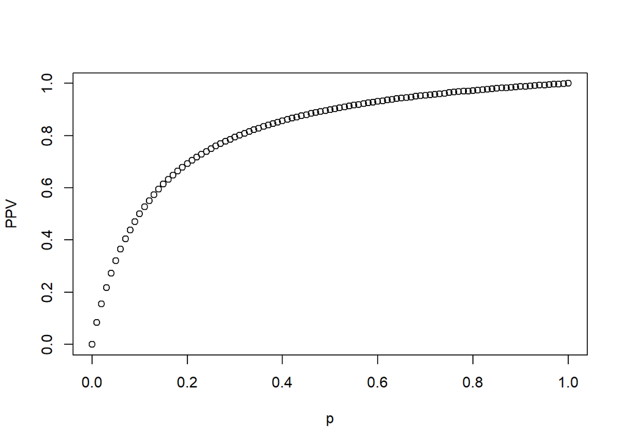

Note that PPV increases as a function of $p$ and for low values of $p$, the PPV can also be quite small - for example, for $p=0.01$, $PPV=$ 0.08, which means that a positive result would mean only an 8% chance of actually having the condition! In contrast, for $p=0.1$, $PPV=$ 0.5, and for $p=0.2$, $PPV=$ 0.69. **Cite some work on biomarkers, maybe some work by Wacholder on PPV, NPV etc** If a test is used in clinical practice, this is a very important consideration and is one reason why, for example, screening tests are not applied to the general population, but rather a population that is already *enriched for some risk factor*, which in effect increases the prevalence of the disease: For example, only performing colonoscopies in individuals only 50, only considering certain prenatal tests in women over 35 etc.

#### How high accuracy can be misleading

In general, there is a trade-off between sensitivity and specificity. **Include the classical threshold plot here?** An extreme example is of setting the test to always be positive - in that case, the sensitivity is 100%, while the specificity is 0%. This can affect other measures, such as the accuracy. For example, if the class with the condition is very small - say, having a prevalence $p=0.1$, then simply setting the test to always be negative will result in an accuracy of 90%. However, this will not help at all in distinguishing between the two classes. This is another reason why using the PPV and NPV may be more useful in practice.

### I’m wondering if we should only include something here on risk prediction in terms of absolute vs relative risk - I think the concepts are simlar, since for absolute risk you’re updating the baseline risk, and the goal is of course risk *prediction* so it would be relevant